# DS 202 - lab #5: Drunk Driving and Fatal Accidents

Dongming Li

11/8/2020

## Questions

```r
library(tidyverse)
library(lubridate)
library(ggplot2)
library(scales)

acc <- read.csv("https://raw.githubusercontent.com/xdaiISU/ds202materials/master/hwlabs/fars2017/accident.csv", stringsAsFactors = FALSE)
Person <- read.csv("https://raw.githubusercontent.com/xdaiISU/ds202materials/master/hwlabs/fars2017/person.csv", stringsAsFactors = FALSE)
state_codes <- read.csv("/users/dongm/oneDrive/Desktop/DS202_Lab5/stateCodes.csv")
make_codes <- read.csv("/users/dongm/oneDrive/Desktop/DS202_Lab5/makeCodes.csv")
GLC <- readxl::read_xlsx("/Users/dongm/oneDrive/Desktop/DS202_Lab5/FRPP_GLC_-_United_StatesSep292020.xlsx")
```

1. Are there some days of the week where more accidents happen than the others (see FARS manual, use variable DAY_WEEK)?

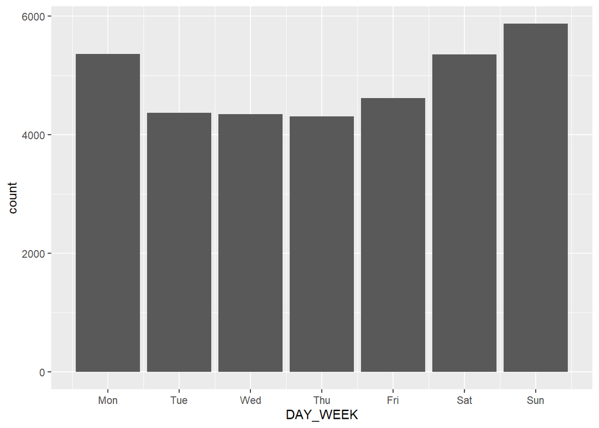

```
In general, Monday, Saturday and Sunday are days of the week that more accidents will happen, especially Sunday.
```

```r
ggplot(acc,aes(x=DAY_WEEK)) + geom_bar()+scale_x_continuous(breaks=1:7,labels=c("Mon","Tue","Wed","Thu","Fri","Sat","Sun"))
```

2. Create a data frame containing the persons who are fatally hurt in the accidents (look up variable INJ_SEV)

```r
fatally_hurt<-Person %>%
  filter(INJ_SEV == '4')
```

3. Create a data frame containing the most dangerous vehicle make in each state. The number of persons fatally hit in the vehicle make is used to assess the (non-)safety of a make. Make sure to handle the missing values appropriately. (look up variable MAKE)

```r
fatally_hurt$MAKE[is.na(fatally_hurt$MAKE)]=99

danger<- fatally_hurt%>%
  group_by(STATE,MAKE)%>%
  summarise(fatal_hurt_number = n())%>%
  group_by(STATE)%>%
  filter(fatal_hurt_number==max(fatal_hurt_number))
```

4. Create a map, and label each state with the most dangerous vehicle. Discuss the definition of the most dangerous vehicle, and what you find from the map. (Hint: Read the description for the STATE and COUNTY columns in the FARS manual. The state & county codes are Geographic Locator Codes (GLCs) from the General Services Administration’s (GSA) publication. Use readxl::read_xlsx to read in the GLCs.)

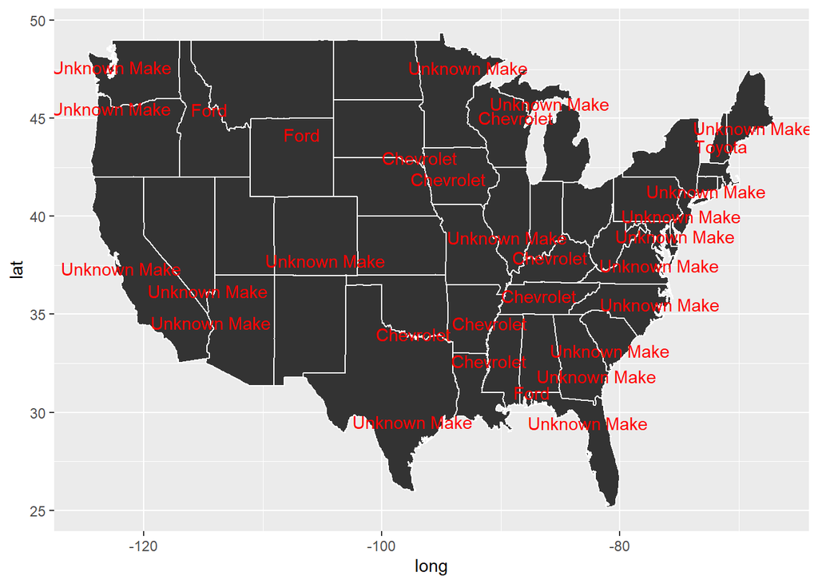

[output not shown]

```r
states <- map_data('state')
state_codes$State <- tolower(state_codes$State)
danger <- danger%>%
  left_join(state_codes, by = c('STATE' = 'Codes'))%>%
  left_join(make_codes, by = c ('MAKE' = 'Codes'))
Map<-danger%>%
  left_join(states, by = c('State' = 'region'))
stateName <- Map %>%
  group_by(State) %>%
  summarize(long=median(long), lat=median(lat))
danger <- danger%>%
  left_join(stateName, by = 'State')
ggplot(Map, aes(x = long, y = lat)) + geom_polygon(aes(group=group), color = 'white') + geom_text(aes(label = Make), color = 'red', data = danger,check_overlap = TRUE)
```

5. Join the accident and person table (work out which variable(s) to use)

```r
ACC_PER<-acc%>%
  left_join(Person,by="ST_CASE")%>%
  distinct(ST_CASE, .keep_all = TRUE)
```

6. Tally the number of accidents by day of the week (DAY_WEEK), hour of the day (HOUR) and gender (SEX). Visualize the results.

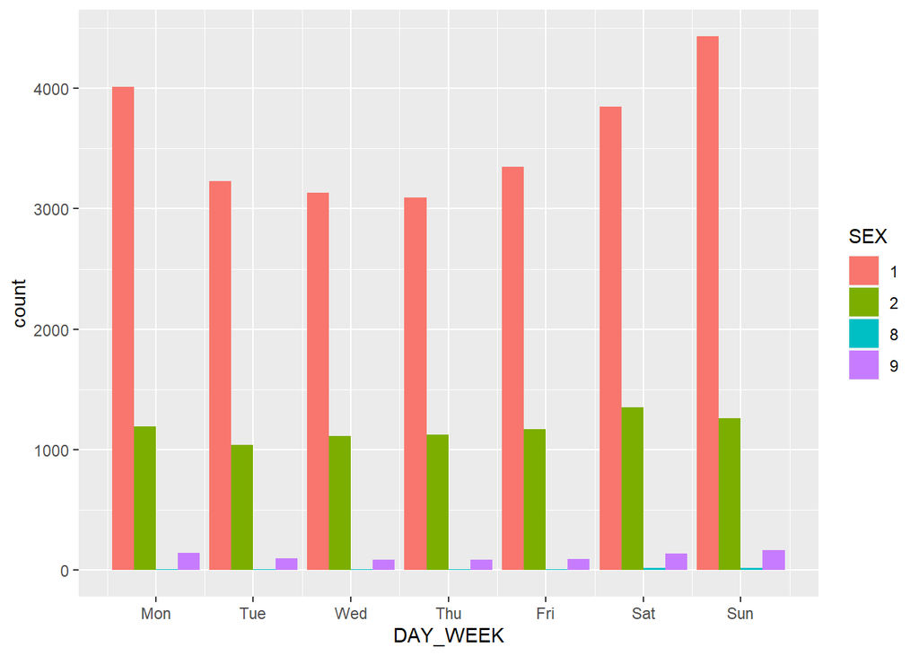

```r
ACC_PER$SEX<-factor(ACC_PER$SEX)
ACC_PER$HOUR.x<-factor(ACC_PER$HOUR.x)
ggplot(ACC_PER,aes(x=DAY_WEEK,fill=SEX)) + geom_bar(position = "dodge")+scale_x_continuous(breaks=1:7,labels=c("Mon","Tue","Wed","Thu","Fri","Sat","Sun"))
```

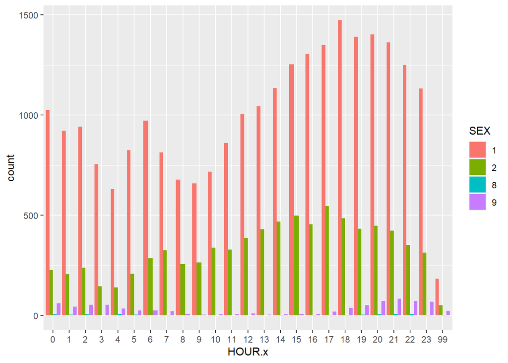

```r
ggplot(ACC_PER,aes(x=HOUR.x,fill=SEX)) + geom_bar(position = "dodge")
```

7. Now plot a choropleth map of the number of deaths on a county level.

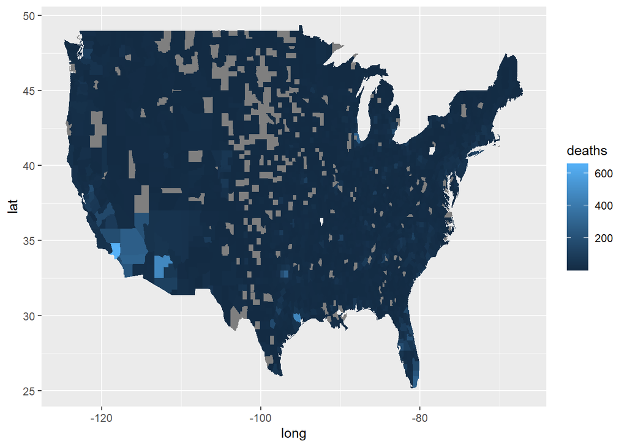

```r
death<-acc %>%
  group_by(STATE, COUNTY) %>%
  summarise(deaths=sum(FATALS))
county <- map_data("county")
GLC <- GLC %>%
  rename(STATE=`State Code`, COUNTY=`County Code`) %>%
  mutate(STATE=as.numeric(STATE), COUNTY=as.numeric(COUNTY))
Map2 <- death %>%
  inner_join(GLC, by=c("STATE", "COUNTY")) %>%
  select(deaths, `State Name`, `County Name`) %>%
  distinct() %>%
  rename(region=`State Name`, subregion=`County Name`) %>%
  mutate(region=tolower(region), subregion=tolower(subregion))%>%
  right_join(county, by=c("region", "subregion"))
Map2 %>%
  ggplot(aes(x = long, y = lat, fill=deaths),color = 'white') +
  geom_polygon(aes(group=group))
```

8. Is summer or winter more dangerous? Does this depend on states? Explore and explain.

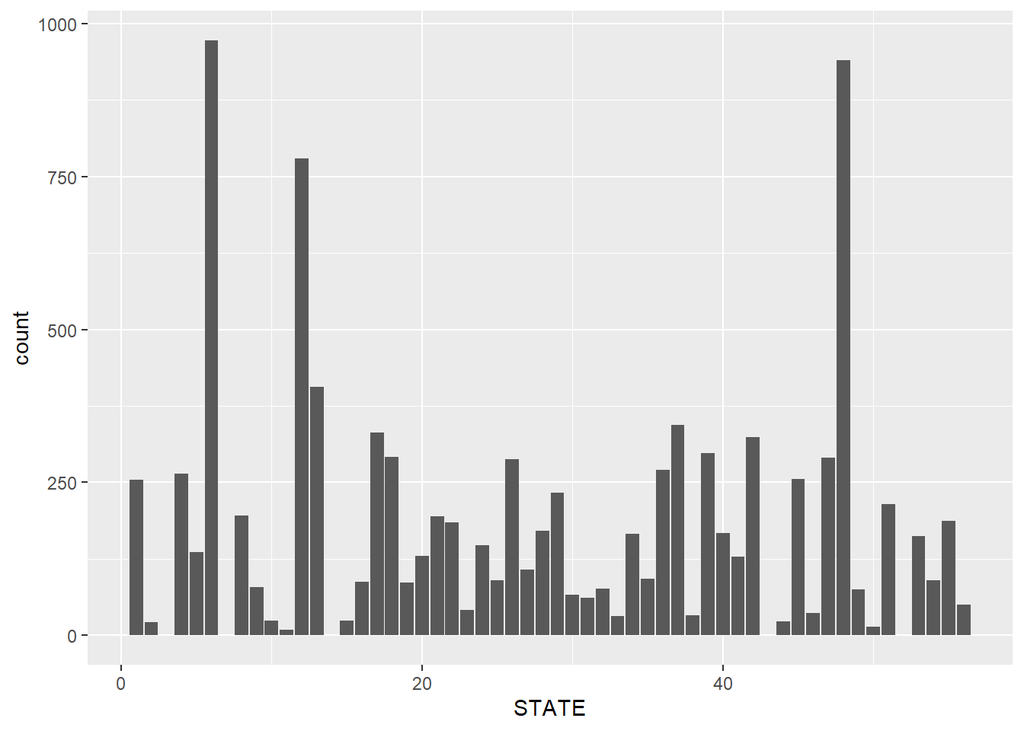

```r
Summer<-fatally_hurt%>%
  filter(MONTH>=5)%>%
  filter(MONTH<=7)%>%
  group_by(STATE)%>%
  summarise(fatal_hurt_number = n())%>%
  group_by(STATE)%>%
  filter(fatal_hurt_number==max(fatal_hurt_number))
ggplot(Summer,aes(x=STATE,weight=fatal_hurt_number)) + geom_bar()
```

```r
sum(Summer$fatal_hurt_number)
```

```
## [1] 9943
```

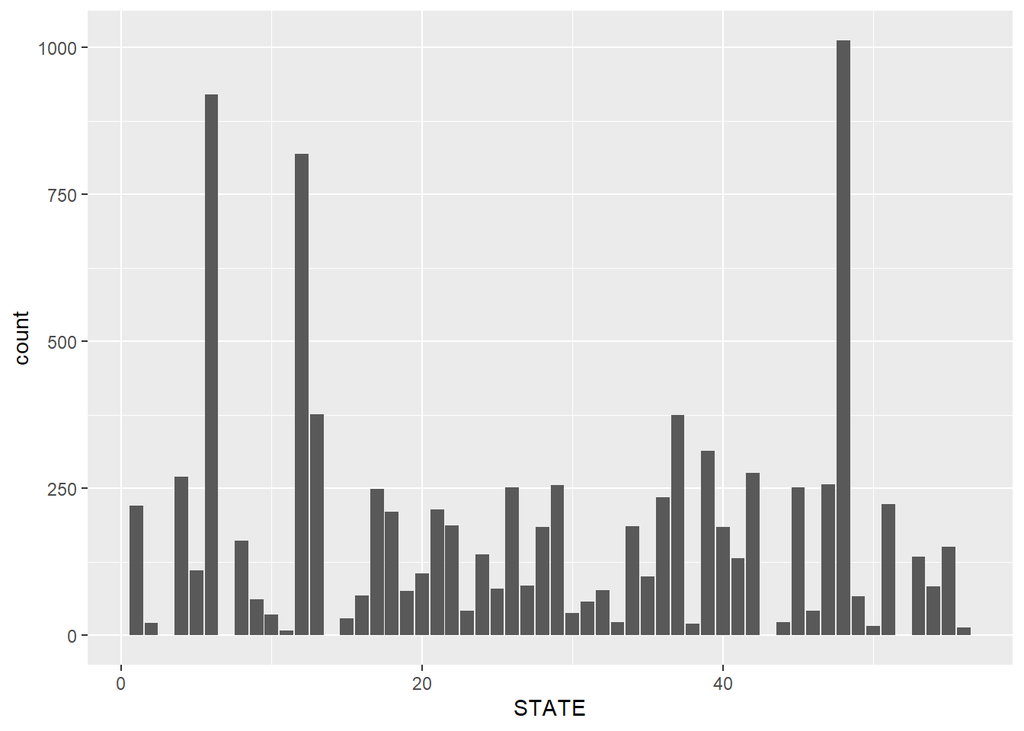

```r
Winter<-fatally_hurt%>%
  filter(MONTH>=10)%>%
  filter(MONTH<=12)%>%
  group_by(STATE)%>%
  summarise(fatal_hurt_number = n())%>%
  group_by(STATE)%>%
  filter(fatal_hurt_number==max(fatal_hurt_number))
ggplot(Winter,aes(x=STATE,weight=fatal_hurt_number)) + geom_bar()
```

```r
sum(Winter$fatal_hurt_number)
```

```
## [1] 9470
```

[output not shown]